# Here, let’s examine some existing packages and functions that are available.

## 1. Reading in data

A common problem I have is getting data into R. We often have a .txt file and we need an object that is usable in R, such as a data frame or a genind obect.

I have include ynpDat.txt. Let’s take a look at it (open it with your text editor of choice). Consider the following:

- What is in it? That is what are we representing?
- Is the data described by populations or individuals?
- Is there a header?
- Task: A handy way to read in data is with the package pegas. Create an Allelic data frame “x” with pegas using the function read.loci. It should look like:

> x  
Allelic data frame: 896 individuals  
95 loci

A common object for population genetics is “genind.” This is usable by numerous programs. Create a genind object named “obj” with loci2genind.

## 2. What is a genind object like?

> obj  
/// GENIND OBJECT /////////

// 896 individuals; 95 loci; 223 alleles; size: 887.6 Kb

// Basic content  
@tab: 896 x 223 matrix of allele counts  
@loc.n.all: number of alleles per locus (range: 2-35)  
@loc.fac: locus factor for the 223 columns of @tab  
@all.names: list of allele names for each locus  
@ploidy: ploidy of each individual (range: 2-2)  
@type: codom  
@call: df2genind(X = as.matrix(x[, attr(x, “locicol”)]), sep = “/”,  
pop = pop, ploidy = ploidy)

// Optional content  
@pop: population of each individual (group size range: 1-102)

There are lots of handy attributes such as ploidy. Let’s explore a couple of these.

e.g. obj@tab, obj@pop, levels(obj@pop)

#### You’ll notice that we have 35 pops listed, but 20 described in the study. Ruh-oh. This happens to me all the time. Here is one way to go about fixing this. I have used “plyr” and not revised it since.

install.packages(“plyr”)  
library(“plyr”)

obj2<-obj

groups<-read.table(“groupingTable.txt”, header=TRUE)

obj2@pop<-mapvalues(obj2@pop,as.character(groups$Code), as.character(groups$Group))

How about now? What exactly happened? What is the pop vector like? The @pop vector can easily be manipulated.

### 3. Let’s do some basic quality control. First thing we should not forget are that some loci are linked to adaptation, those on Omy05, and won’t reflect neutral divergences. Futhermore, you may want to remove additional loci to merge datasets.

Subsetting is really easy, such as:

obj2[loc=c(“SH10077163”)]

Likewise for populations:

obj2[pop=c(“TUOL”)]

Unfortunately, I haven’t found a way to negate, such as != with geninds. Here is what I have done, let me know if you find a better way.

obj3<-obj2[loc = c(“SH95489423”,“SH10077163”,“SH102510682”,“SH105115367”,“SH108735311”,  
“SH110201359”,“SH11312873”,“SH117286374”,“SH119892365”,“OMGH1PROM1SNP1”,“Omy_arp630”,  
“SH96222125”,“SH100974386”,“SH102867443”,“SH105385406”,“SH109243222”,“SH110362585”,  
“SH114315438”,“SH117370400”,“SH120255332”,“SH128851273”,“Omy_aspAT123”,“Omy_g1282”,  
“SH9707773”,“SH101554306”,“SH103350395”,“SH105386347”,“SH109525403”,“SH110689148”,  
“SH117540259”,“SH120950569”,“Omy_COX1221”,“Omy_gh475”,“SH97954618”,“SH101770410”,  
“SH103577379”,“SH105714265”,“SH109651445”,“SH111666301”,“SH114587480”,“SH11781581”,  
“SH129870756”,“Omy_nramp146”,“Omy_gsdf291”,“SH98188405”,“SH101832195”,“SH103705558”,  
“SH106172332”,“SH109693461”,“SH112208328”,“SH114976223”,“SH118175396”,“SH123044128”,  
“SH130524160”,“Omy_Ogo4304”,“Omy_mapK3103”,“SH98409549”,“SH101993189”,“SH104519624”,  
“SH106313445”,“SH109874148”,“SH112301202”,“SH115987812”,“SH11865491”,“SH12599861”,  
“SH130720100”,“OMY_PEPAINT6”,“Omy_mcsf371”,“SH98683165”,“SH102420634”,“SH105075162”,  
“SH107074217”,“SH110064419”,“SH11282082”,“SH116733349”,“SH118938341”,“SH131460646”, “ONMYCRBF_1SNP1”,“SH95318147”,“SH99300202”,“SH102505102”,“SH105105448”,“SH10728569”, “SH110078294”,“SH113109205”,“SH11725996”,“SH119108357”,“SH127510920”,“SH131965120”)]

##### Those are a couple of really common things that happen to me.

The package poppr:

Use missing.no to remove loci and individuals missing with at least 5% missing data from obj3. My obj3 now contains:

867 individuals; 87 loci; 174 alleles; size: 690.8 Kb

### 4. Basic characteristics. Again, we are saved by the fact that someone has done a lot of work for us already. for instance, we can use poppr’s poppr function on obj3. There are a lot of things going on here….

table<-poppr(obj3)

It should start like this:

Pop N MLG eMLG SE H G lambda E.5 Hexp Ia rbarD File  
1 YOSV 81 80 9.99 0.117 4.38 79 0.987 0.993 0.342 0.2751 0.003314 obj3  
2 SFMC 45 45 10.00 0.000 3.81 45 0.978 1.000 0.335 -0.0459 -0.000556 obj3  
3 CRAN 27 27 10.00 0.000 3.30 27 0.963 1.000 0.311 0.3821 0.005096 obj3

Anything not look good? In the entire table… Let’s filter it.

table[table$N>10,]

Task: Create a fourth genind object “filtered” including only populaitons greater than 10 individuals.

- Remember, there is always more than one way to accomplish a task in R.
- Hint: you can susbet a genind object with pop= like loc=, so all you need is a vector of desired pops.

> length(levels(filtered@pop)) [1] 16

### 5. AARRGGGHHH, but we haven’t done any analyses yet!! I know, but this up front wrangling is the most time consuming and I wanted to provide several examples of cases you may experience first hand.

### 6. Population structure. Commonly, we want to know if we have significantly differentiated populations. With a genind object we have several options.

#### 6A: Fst

Install the package hierfstat and load it. It has the handy funtion, pairwise.fst. You can quite easily create a Fst matrix with it.

[output not shown]

This is a good place to start when looking at relatedness of populations.

fsts<-pairwise.fst(filtered)

Would you say that our data have high Fst values? This is discussed a bit in Campbell and Pearse (2017).

#### 6B: Phylogenetic trees

I have a long history with fish phylogenetics, and therefore making phylogenetic trees is something I often do when looking at populations.

Poppr has a handly function, “aboot”. Let’s look it up in the manual. My suggestion is to use chord distances and generate a Neighbor-Joining population level tree using predefined populations (the @pop vector).

##### Generate tree with aboot considering the following:

1. Neighbor-Joining
2. Chord-distances
3. A meaningful nuber of resamplings (at least 1000)
4. A cutoff for support

You may change the presentation with “plot.phylo” in the ape package e.g.

plot.phylo(treeF, type=“radial”,show.node.label = TRUE)

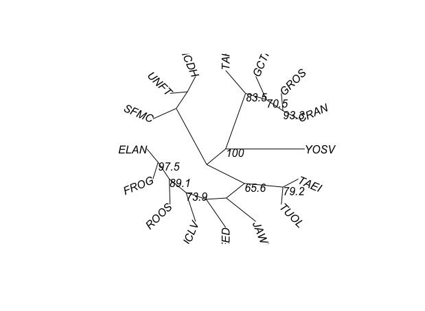

This Tree Is Not Pretty

I always process after the fact with separate programs for publciation quality trees.

5. What relationships are meaningful on the tree in context of geography?

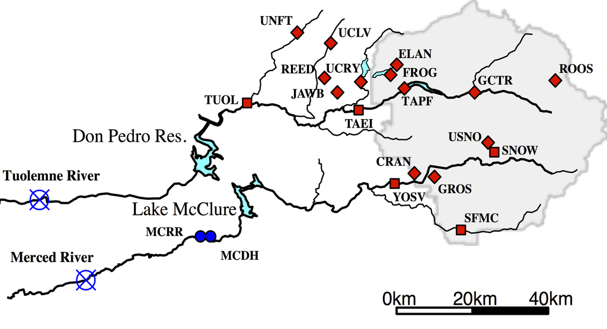

#### 6C: Objective Clustering

STRUCTURE is a perennial favorite, but we will look at DAPC, part of the adegenet package on another page. But, let’s save our work.

save(filtered, file=“filtered.rda”)